# Logistic regression & Neural networks

内容

1. 5分钟复习
2. GLM求解
3. 从Logistic regression到Neural networks
4. Back propagation
5. 应用：手写字识别

## 5分钟复习

**GLMs模型**

$y$ 的均值是 $X\beta$的函数

\begin{align*} \mathbb{E} (y | X) &= g^{-1} \left( X \beta \right) \end{align*}

$g$为*link function*, 是确定和已知的函数。

**Logistic regression**

采用logit function 为$g$，模型形式为

\begin{align*} \mathbb{E} (y | X) &= \text{logit}^{-1} \left( X \beta \right) \\ &= \frac{1}{1 + e^{- X \beta}} \end{align*}

$y_i$服从Bernoilli分布, 其未知参数只有$p_i = \mathbb{P} (y = 1)$，因此对于样本点$i$，似然函数为 \begin{align*} L(y_i | p_i) &= p_i^{y_i} \cdot (1 - p_i)^{1 - y_i} \end{align*}

将其写成指数分布族的形式 \begin{align} L(y_i | p_i) &= (1 - p_i) \cdot \left( \frac{p_i}{1 - p_i} \right)^{y_i}\\ &= (1 - p_i) \cdot \text{exp} \left( y_i \cdot \color{#FF6666}{ \text{log} \left( \frac{p_i}{1 - p_i} \right) } \right) \end{align}

\begin{align*} \eta_i &= \text{log} \left( \frac{p_i}{1 - p_i} \right) \\ &= \text{logit} (p_i) \end{align*}

因此, 不妨令 $\eta_i$ 是 $x_i$的线性函数: \begin{align*} \eta_i &= x_i^t \beta \end{align*}

这时，$g$是logit function.

于是有 \begin{align*} \text{log} \left( \frac{p_i}{1 - p_i} \right) &= x_i^t \beta \\ \frac{p_i}{1 - p_i} &= e^{x_i^t \beta} \\ p_i &= (1 - p_i) \cdot e^{x_i^t \beta} \\ \left( 1 + e^{x_i^t \beta} \right) p_i &= e^{x_i^t \beta} \\ p_i &= \frac{e^{x_i^t \beta}}{1 + e^{x_i^t \beta}} \\ &= \frac{1}{1 + e^{-x_i^t \beta}} \end{align*}

GLM模型:$\mathbb{E} (y | X) = g^{-1} \left( X \beta \right)$

若$y_i$是独立伯努利实验，则模型为 \begin{align*} \mathbb{E} (y | X) &= \frac{1}{1 + e^{-X\beta}} \end{align*}

$x^t \beta$ 和 $p_i$ 之间的关系?

[figure not shown]

## 如何通过加权最小二乘求解GLM

对于样本点$i$，似然函数中有两项与$p_i$有关： \begin{align*} L_i(y_i | p_i) &= \text{exp} \left\{y_i \cdot \color{red}{\log\left( \frac{p_i}{1-p_i}\right)} + \color{blue}{ \log(1 - p_i)} \right\} \\ \end{align*}

- $\color{red}{\log\left( \frac{p_i}{1-p_i}\right)}$: the projection of the regression vector $x_i^t \beta$.
- $\color{blue}{\log(1 - p_i)}$:

\begin{align*} p_i &= \frac{1}{1 + e^{-x_i^t \beta}} \\ 1 - p_i &= \frac{ e^{-x_i^t \beta}}{1 + e^{-x_i^t \beta}} \\ &=\frac{ 1}{1 + e^{x_i^t \beta}} \\ \log(1 - p_i) &= -1 \cdot \log(1 + e^{x_i^t \beta}) \end{align*}

对数似然函数为: \begin{align*} l(y_i | x_i, \beta) &= \sum_i \left(y_i \cdot x_i^t \beta - \log(1 + e^{x_i^t \beta}) \right) \\ &= y^t X \beta - \log(1 + e^{X\beta}) \end{align*}

下面计算极大似然估计量，即令对数似然函数导数=0。

导数是

\begin{align*} \nabla_\beta l(y_i | x_i, \beta) &= \nabla y^t X \beta - \nabla \log(1 + e^{X\beta}) \\ &= X^t y - \nabla \log(1 + e^{X\beta}) \end{align*}

第二项可以通过每一个$\beta_k$的梯度来计算。

**对于第二项**

根据链式法则

\begin{align*} \frac{\partial}{\partial \beta_k} \log(1 + e^{X \beta}) &= \frac{1}{1 + e^{X \beta}} \cdot x_k^t \cdot e^{X \beta} \end{align*}

将其简化成与$p$有关的形式:

\begin{align*} \frac{1}{1 + e^{X \beta}} \cdot x_k^t \cdot e^{X \beta} &= x_k^t p \end{align*}

写成向量形式：

\begin{align*} \nabla \log(1 + e^{X\beta}) &= X^t p \end{align*}

因此，对数似然梯度的显式形式：

\begin{align*} \nabla_\beta l(y_i | x_i, \beta) &= X^t y - \nabla \log(1 + e^{X\beta}) \\ &= X^t y - X^t p \\ &= X^t (y - p) \end{align*}

- 不能简单地令其为零，$ p $是$ X $的非线性函数
- intuition:逻辑回归中的残差应该与$ X $矩阵不相关（类似线性回归）。
- 要找到函数$ \nabla_ \beta l（y_i | x_i，\beta）$零值的数值解，可使用Newton-Raphson方法。

使用Newton-Raphson确定$f$的最优值的标量形式为 \begin{align*} \beta^{(k+1)} &= \beta^{(k)} - \frac{f\,'(\beta^{(k)})}{f\,''(\beta^{(k)})} \end{align*}

相应地，向量形式为

\begin{align*} \beta^{(k+1)} &= \beta^{(k)} - H^{-1}(\beta^{(k)}) \nabla f\,(\beta^{(k)}) \end{align*}

其中$ H $是所有二阶偏导数的Hessian矩阵， $f$是原始的对数似然函数。

对数似然的Hessian是什么？

梯度为$X^t (y - p)$，因此Hessian仅取决于$X^t p$。

Hessian中每个元素：

\begin{align*} \frac{\partial^2 l(\beta)}{\partial \beta_j \partial \beta_k} &= \frac{\partial}{\partial \beta_j} \sum_i x_{i,k} \cdot p_i \\ &= \sum_i x_{i,k} \cdot \frac{\partial p_i}{\partial \beta_j} \\ \end{align*}

$p_i$相对于$\beta_j$的偏导数由下式给出： \begin{align*} \frac{\partial p_i}{\partial \beta_j} &= \frac{\partial}{\partial \beta_j} \frac{1}{1+e^{-x_i^t \beta}} \\ &= \frac{-1}{(1+e^{-x_i^t \beta})^2} \cdot -1 \cdot x_{i,j} \cdot e^{-x_i^t \beta} \\ &= x_{i,j} \cdot \left(\frac{1}{1+e^{-x_i^t \beta}} \right) \cdot \left(\frac{e^{-x_i^t \beta}}{1+e^{-x_i^t \beta}} \right) \\ &= x_{i,j} \cdot p_i \cdot (1 - p_i) \\ &= x_{i,j} \cdot \text{Var}(y_i) \end{align*}

- （实际不需要最后一行）

于是，Hessian矩阵为 \begin{align*} H l(y | x_i, \beta) &= - X^t D X \end{align*}

其中，$D$是 $n\times n$对角矩阵，每个元素是$p_i\cdot(1-p_i)$。

因此，Newton-Raphson法实际上是

\begin{align*} \beta^{(k+1)} &= \beta^{(k)} - H^{-1}(\beta^{(k)}) \nabla f\,(\beta^{(k)}) \\ &= \beta^{(k)} + (X^t D X)^{-1} X^t (y - p^{(k)}) \end{align*}

采用合适的$z$将上式写为

\begin{align*} \beta^{(k+1)} &= (X^t D X)^{-1} (X^t D X) \beta^{(k)} + (X^t D X)^{-1} X^t (y - p^{(k)}) \\ &= (X^t D X)^{-1} X^t D (X \beta^{(k)} + D^{-1} (y - p) ) \\ &= (X^t D X)^{-1} X^t D z \end{align*}

- 因此，解决逻辑回归等于解决一系列加权最小二乘模型

$$ \beta^{(k+1)} = \underset{b}{\operatorname{argmin}} \left\{ || D^{1/2} (z - Xb) ||_2^2 \right\} $$

```r
n <- 1000
p <- 10
X <- matrix(rnorm(n*p),ncol=p)
beta <- runif(p)
y <- as.numeric(X%*%beta + rnorm(n) > 0)

# Fit a model; what do you think the iter is?
out <- glm(y ~ X - 1, family=binomial())
out$iter
```

6

```r
# Show that the residuals are orthogonal to col space of X
t(X) %*% (y - predict(out, type="response"))
```

A matrix: 10 × 1 of type dbl

| 6.517880e-10 |
| --- |
| 4.703924e-10 |
| 4.595624e-10 |
| 6.891673e-11 |
| 3.829013e-10 |
| 3.548814e-10 |
| 3.784546e-10 |
| 1.510716e-10 |
| 2.657839e-12 |
| 3.663790e-11 |

```r
# Fit GLM IRWLS
beta <- rep(0,p)
for (k in 1:10) {
  prob <- 1 / (1 + exp(-X %*% beta))
  D <- diag(as.numeric(prob*(1-prob)))
  z <- X %*% beta + (y - prob) / diag(D)
  beta <- qr.solve(crossprod(X, D %*% X), crossprod(X, D %*% z))
  print(sum((beta - coef(out))^2))
}
```

```
[1] 3.381727
[1] 0.802604
[1] 0.059604
[1] 0.0003847109
[1] 1.687253e-08
[1] 3.209456e-17
[1] 2.503075e-21
[1] 2.502413e-21
[1] 2.502499e-21
[1] 2.502213e-21
```

## Logistic regression & Neural networks

Logistic regression：仅含有一个神经元的单层的神经网络

[figure not shown]

**Activation functions**

- Logistic regression

\begin{align*} \text{logit} (p_i) &= \text{log} \left( \frac{p_i}{1 - p_i} \right) \\ \text{logit}^{-1} \left( X \beta \right) & = \frac{1}{1 + e^{- X \beta}} \end{align*}

- Neural networks

$$\sigma(x \cdot w + b) = \frac{1}{1 + e^{-(x \cdot w + b)}}$$

The inverse of the logit function is the sigmoid function .

Feed-forward network (前馈网络)

- 节点连接只有一个方向，朝一个方向传送信息
- 每个隐藏层内部，不允许相互连接（RNN允许）

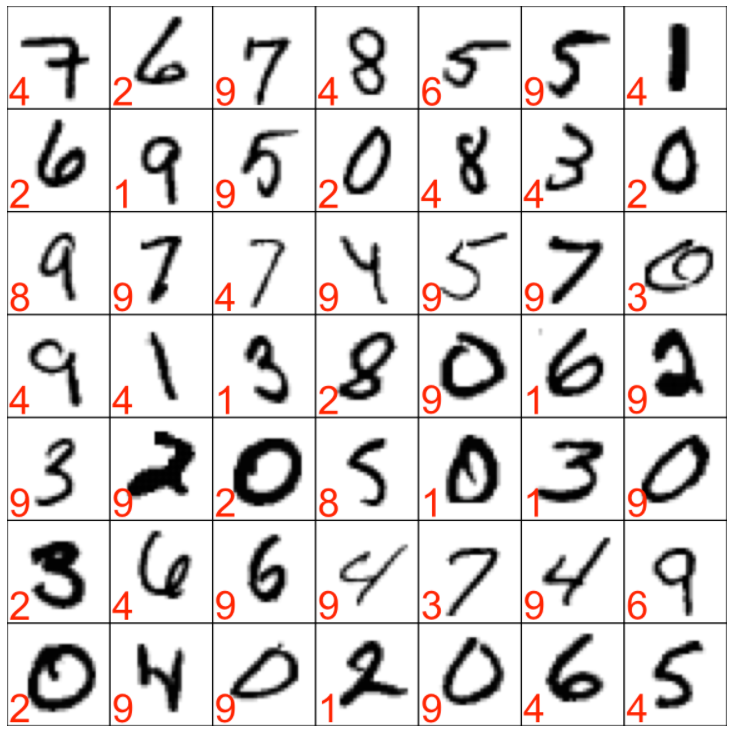

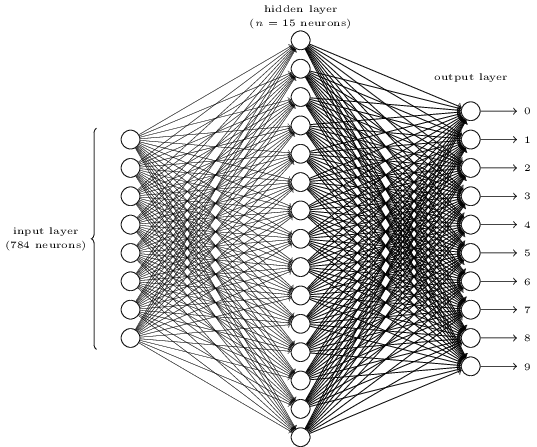

查看哪个输出神经元具有最大输出，就分为哪一类。

如何求解weights和bias?

如果是单层、单个神经元，则可以用logistic regression 或SVM等。

cost function ( loss function )

squared error loss: \begin{align*} C(w, b) &= \frac{1}{2n} \sum_i (y_i - \widehat{y}(x_i) )^2 \end{align*}

**Optimization problem & gradient descent**

\begin{align*} w_{k+1} &= w_k - \eta \cdot \nabla_w C \\ b_{k+1} &= b_k - \eta \cdot \nabla_b C \end{align*}

- learning rate, $\eta > 0$

Decomposable cost function

神经网络中的成本函数能够在样本上分解：

\begin{align*} C &= \frac{1}{n} \sum_i C_i \end{align*}

For the individual costs $C_i$ of the $i$'th sample.

Decomposable cost function

从训练集中取一个子集$M \subseteq \{1, 2, \ldots n \}$，子集大小为$m$. 可以用子集的梯度来近似： \begin{align*} \frac{\sum_{i \in M} \nabla C_i}{m} &\approx \frac{\sum_{i=1}^n \nabla C_i}{n} \approx \nabla C \end{align*}

Stochastic gradient descent (SGD)

- Stochastic gradient descent uses this idea to speed up the process of doing gradient descent.
- the input data are randomly partitioned into disjoint groups $M_1, M_2, \ldots, M_{n/m}$.
- update：

\begin{align*} w_{k+1} &= w_k - \frac{\eta}{m} \sum_{i \in M_1} \nabla C_i \\ w_{k+2} &= w_{k+1} - \frac{\eta}{m} \sum_{i \in M_2} \nabla C_i \\ &\vdots \\ w_{k+n/m+1} &= w_{k+n/m} - \frac{\eta}{m} \sum_{i \in M_{n/m}} \nabla C_i \end{align*}

Each set $M_j$ is called a mini-batch and going through the entire dataset as above is called an epoch .

Stochastic gradient descent (SGD)

main tuning parameters:

- size of themini-batch ($m$)
- the learning rate ($\eta$)
- number of epochs (E)

为了便于理解，下面以OLS为例，来看SGD是怎么做的。

SGD Examples: OLS

\begin{align*} f(\beta) &= \frac{1}{n} \cdot \sum_i f_i(\beta) \\ &= \frac{1}{n} \cdot \sum_i (y_i - x_i \beta)^2 \\ &= \frac{1}{n} \cdot \sum_i (y_i^2 + \beta^t x_i^t x_i \beta - 2 y_i x_i \beta) \end{align*}

SGD Examples: OLS

The gradient of $f$: \begin{align*} \nabla f &= \frac{1}{n} \cdot \sum_i f_i(\beta) \\ &= \frac{1}{n} \cdot \sum_i \nabla f_i(\beta) \\ &= \frac{2}{n} \cdot \sum_i (x_i^t x_i \beta - x_i^t y_i) \end{align*}

使用大小为$m$的mini-batch $M$来近似 \begin{align*} \nabla f &\approx \frac{2}{m} \cdot \sum_{i \in M} (x_i^t x_i \beta - x_i^t y_i) \end{align*}

```r
set.seed(42)
n <- 1000
p <- 10
X <- matrix(rnorm(n*p),ncol=p)
beta <- 1 / 1:p
y <- X %*% beta + rnorm(n, sd=0.5)

betaOls <- coef(lm(y ~ X - 1))
round(betaOls,2)
```

**X1**

0.99

**X2**

0.49

**X3**

0.34

**X4**

0.26

**X5**

0.21

**X6**

0.16

**X7**

0.14

**X8**

0.1

**X9**

0.1

**X10**

0.09

```r
m <- 5
miniBatchIndex <- matrix(sample(1:n),ncol=m)
head(miniBatchIndex)
```

A matrix: 6 × 5 of type int

| 603 | 123 | 460 | 104 | 935 |
| --- | --- | --- | --- | --- |
| 400 | 515 | 693 | 42 | 381 |
| 447 | 717 | 774 | 720 | 949 |
| 389 | 474 | 463 | 740 | 155 |
| 423 | 610 | 656 | 623 | 966 |
| 646 | 211 | 569 | 911 | 768 |

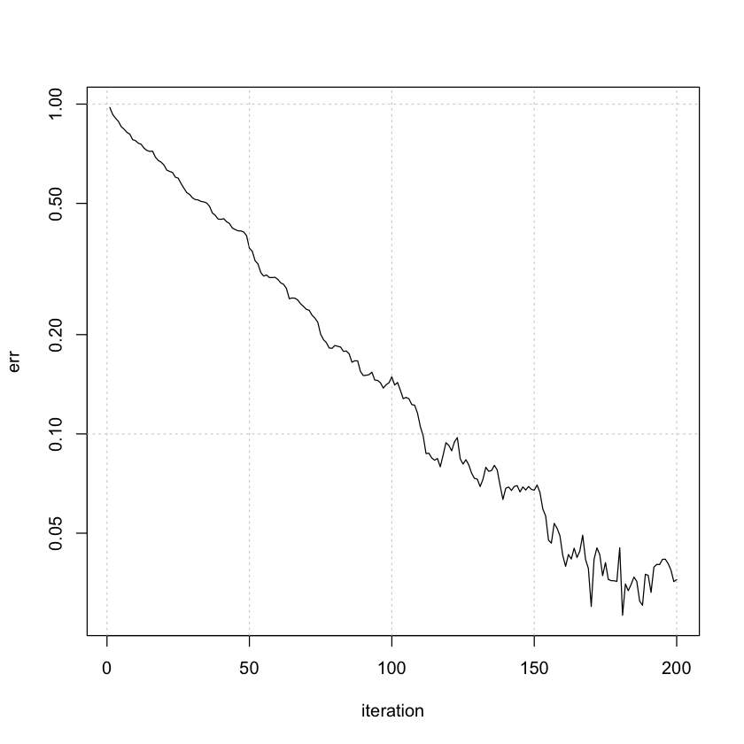

```r
eta <- 0.01
b <- rep(0, p)
err <- rep(NA, nrow(miniBatchIndex))
for (j in 1:nrow(miniBatchIndex)) {
  ind <- miniBatchIndex[j,]
  gradMini <- (2/m) * ((t(X[ind,]) %*% X[ind,]) %*% b - t(X[ind,]) %*% y[ind])
  b <- b - eta * gradMini
  err[j] <- max(abs(b - betaOls))
}

plot(err, log="y", type="l", xlab="iteration")
grid()
```

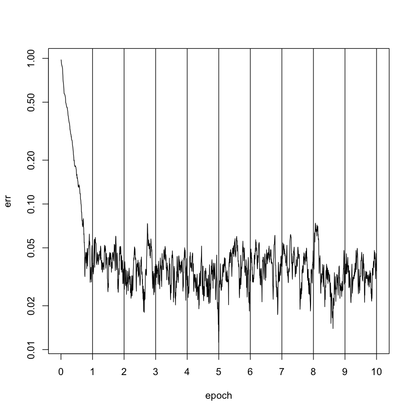

```r
eta <- 0.01
b <- rep(0, p)
E <- 10
err <- rep(NA, nrow(miniBatchIndex)*E)
for (k in 1:E) {
  miniBatchIndex <- matrix(sample(1:n),ncol=m)
  for (j in 1:nrow(miniBatchIndex)) {
    ind <- miniBatchIndex[j,]
    gradMini <- (1/m) * (2 * (t(X[ind,]) %*% X[ind,]) %*% b - 2 * t(X[ind,]) %*% y[ind])
    b <- b - eta * gradMini
    err[j+(k-1)*nrow(miniBatchIndex)] <- max(abs(b - betaOls))
  }
}

plot(err, log="y", type="l", axes=FALSE, xlab="epoch")
box()
axis(2)
axis(1, at=(0:E)*nrow(miniBatchIndex), 0:E)
abline(v=(1:E)*nrow(miniBatchIndex))
```

Stochastic gradient descent (SGD)

- Stochastic gradient descent uses this idea to speed up the process of doing gradient descent.
- the input data are randomly partitioned into disjoint groups $M_1, M_2, \ldots, M_{n/m}$.
- update：

\begin{align*} w_{k+1} &= w_k - \frac{\eta}{m} \sum_{i \in M_1} \nabla C_i \\ w_{k+2} &= w_{k+1} - \frac{\eta}{m} \sum_{i \in M_2} \nabla C_i \\ &\vdots \\ w_{k+n/m+1} &= w_{k+n/m} - \frac{\eta}{m} \sum_{i \in M_{n/m}} \nabla C_i \end{align*}

- 如何计算$\nabla C_i$?

## back-propagation

一些数学符号

- $w^{l}_{j,k}$ ： the weight of node $k$ in layer $l-1$ as applied by node $j$ in layer $l$.
- $b^l_j$： the bias of node $j$ of layer $l$
- $z^l_j$： The weighted input emitted from node $j$ in layer $l$；类似logsitic regression 中的$X \beta$
- $a^l_j$： $a^l_j= \sigma(z^l_j) $

这些符号之间的关系

\begin{align*} a^l_j &= \sigma(z^l_j) \\ &= \sigma(\sum_k w^l_{jk} a_k^{l-1} + b^l_j) \end{align*}

（最后一个数学符号）error functions:

\begin{align*} \color{blue}{\delta_j^l} &= \frac{\partial C}{ \partial z_j^l} \end{align*}

假设神经网络共有$L$层，那么cost function为：

\begin{align*} C(w, b) &= \sum_k (y_k - a_k^L)^2 \end{align*}

*k是输出的维度标号，y可以是多元的*

Feed-forward step

对于最靠近输出的一层:

\begin{align*} \delta_j^L &= \frac{\partial C}{ \partial z_j^L} \\ &= \frac{\partial C}{ \partial a_j^L} \cdot \frac{\partial a_j^L}{ \partial z_j^L} \\ &= \frac{\partial C}{ \partial a_j^L} \cdot \sigma'(z_j^L) \end{align*}

Feed-forward step

第一项:

\begin{align*} \frac{\partial C}{ \partial a_j^L} &= \frac{\partial}{ \partial a_j^L} \sum_k (y_k - a_k^L)^2 \\ &= 2 \cdot (a_j^L - y_j) \end{align*}

第二项:

\begin{align*} \sigma'(z) &= \sigma(z) \cdot (1 - \sigma(z)) \end{align*}

Back-propagation step

将$\delta_j^l$和$\delta_j^{l+1}$联系起来：

\begin{align*} \delta_j^l &= \frac{\partial C}{ \partial z_j^l} \\ &= \sum_k \frac{\partial C}{ \partial z_k^{l+1}} \cdot \frac{\partial z_k^{l+1}}{ \partial z_j^l} \\ &= \sum_k \delta_k^{l+1} \cdot \frac{\partial z_k^{l+1}}{ \partial z_j^l} \end{align*}

对于导数这一项，有

\begin{align*} z^{l+1}_k &= \sum_{i} w^{l+1}_{ki} a^l_i + b_k^{l+1} \\ &= \sum_i w^{l+1}_{ki} \sigma(z_i^l) + b_k^{l+1} \end{align*}

Back-propagation step

于是，有 \begin{align*} \frac{\partial z^{l+1}_k}{ \partial z^{l}_j} &= \frac{\partial}{ \partial z^{l}_j} \left( \sum_i w^{l+1}_{ki} \sigma(z_j^l) + b_k^{l+1} \right) \\ &= w^{l+1}_{kj} \cdot \sigma'(z_j^l) \end{align*}

带回到最初的式子中，有 \begin{align*} \delta_j^l &= \sum_k \delta_k^{l+1} \cdot w^{l+1}_{kj} \cdot \sigma'(z_j^l) \end{align*}

**在每个节点上，将errors和bias联系起来**

\begin{align*} \delta_j^l &= \frac{\partial C}{ \partial z_j^l} \\ &=\frac{\partial C}{ \partial b_j^l} \cdot \frac{\partial b_j^l}{ \partial z_j^l} \\ &=\frac{\partial C}{ \partial b_j^l} \end{align*}

**在每个节点上，将errors和weights联系起来**

\begin{align*} \delta_j^l &= \frac{\partial C}{ \partial z_j^l} \\ &=\frac{\partial C}{ \partial w_{jk}^l} \cdot \frac{\partial w_{jk}^l}{ \partial z_j^l} \\ &=\frac{\partial C}{ \partial w_{jk}^l} \cdot \frac{1}{a^{l-1}_k} \end{align*}

也即 \begin{align*} \frac{\partial C}{ \partial w_{jk}^l} &= a^{l-1}_k \delta_j^l \end{align*}

**小结**

\begin{align*} \delta_j^L &= \nabla_{a^L} C \circ \sigma'(z^L) \\ \delta_j^l &= ((w^{l+1})^T \delta^{l+1}) \circ \sigma'(z^l) \\ \frac{\partial C}{\partial b^l_j} &= \delta^l_j \\ \frac{\partial C}{\partial w^l_{jk}} &= a^{l-1}_k \delta^l_j \end{align*}

*符号$\circ$是Hadamard product*

The back-propagation algorithm

- Select an element $i$ from the current minibatch and calculate the weighted inputs $z$ and activations $a$ for every layer using a forward pass through the network
- Now, use these values to calculate the errors $\delta$ for each layer, starting at the last hidden layer and working backwards, using back-propagation
- Calculate $\nabla_w C_i$ and $\nabla_b C_i$ using the last two equations
- Repeat for all samples in the minibatch, to get: \begin{align*} \frac{\sum_{i \in M} \nabla_w C_i}{|M|} \approx \nabla_w C \quad \quad \quad \frac{\sum_{i \in M} \nabla_b C_i}{|M|} \approx \nabla_b C \end{align*}
- Update the weights and biases by (the estimates of) $-\eta \cdot \nabla_w C$ and $-\eta \cdot \nabla_b C$, respectively
- Repeat over every mini-batch, and for the desired number of epochs

一个小算例

https://www.cnblogs.com/charlotte77/p/5629865.html

```r
train <- read.csv("mnist_train.psv", as.is=TRUE, header=FALSE, sep = "|", stringsAsFactors = FALSE)
test <- read.csv("mnist_test.psv", as.is=TRUE, header=FALSE, sep = "|", stringsAsFactors = FALSE)
dim(train)
dim(test)
```

1. 7291

2. 257

1. 2007

2. 257

```r
X <- as.matrix(train[,-1]) / 256
Xtest <- as.matrix(test[,-1]) / 256

# convert the categorical response into 10 indicator functions:
Y <- matrix(0, nrow=nrow(X), ncol=10)
Ytest <- matrix(0, nrow=nrow(Xtest), ncol=10)
for (i in 0:9) {
  Y[train[,1] == i,i+1] <- 1
  Ytest[test[,1] == i,i+1] <- 1
}
head(Y)
```

A matrix: 6 × 10 of type dbl

| 0 | 0 | 0 | 0 | 0 | 0 | 1 | 0 | 0 | 0 |
| --- | --- | --- | --- | --- | --- | --- | --- | --- | --- |
| 0 | 0 | 0 | 0 | 0 | 1 | 0 | 0 | 0 | 0 |
| 0 | 0 | 0 | 0 | 1 | 0 | 0 | 0 | 0 | 0 |
| 0 | 0 | 0 | 0 | 0 | 0 | 0 | 1 | 0 | 0 |
| 0 | 0 | 0 | 1 | 0 | 0 | 0 | 0 | 0 | 0 |
| 0 | 0 | 0 | 0 | 0 | 0 | 1 | 0 | 0 | 0 |

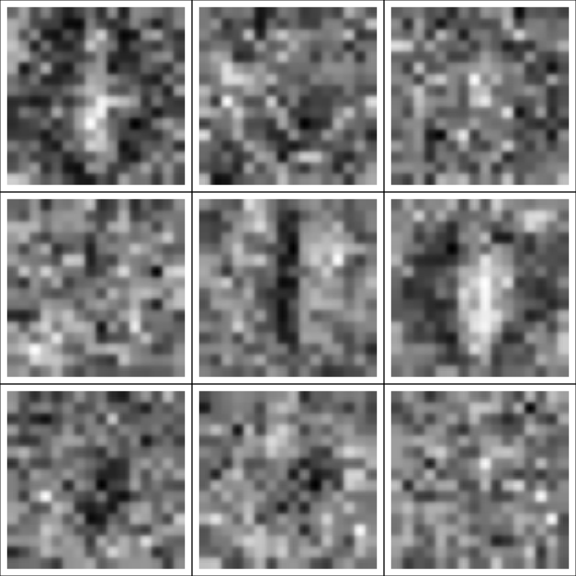

```r
nn <- nnetObj(sizes <- c(256,9,10))
nn2 <- sgd(nn, X, Y, Xtest, Ytest, m=1, epochs=15, eta=0.2, FALSE)

par(mfrow=c(3,3))
par(mar=c(0,0,0,0))
for (j in 1:9) {
  z <- nn2$w[[1]][j,]
  z <- (z - min(z)) / (max(z) - min(z))
  z <- matrix(as.matrix(z),16,16,byrow=TRUE)
  plot(0,0,axes=FALSE,xlab="",ylab="",main="")
  rasterImage((1 - z),-1,-1,1,1)
  box()
}
```

Thank you!

shan.lu@cufe.edu.cn